# Student Sleep Habits and Mental Health: Impact on Academic Performance

MD. NUMMAN(23-54538-3), S.T.M. MUSTAFA TAUSIF(23-51469-1), MD. WASIF HASAN (23-50938-1), MD. SABBIR HOSSAIN ROHAN (23-50753-1)

28 August 2026

```r
required_packages <- c(
  "tidyverse",
  "skimr",
  "moments",
  "ggcorrplot",
  "factoextra",
  "caret",
  "rpart",
  "rpart.plot",
  "randomForest",
  "knitr",
  "kableExtra",
  "rsample"
)

for (pkg in required_packages) {
  if (!require(pkg, character.only = TRUE)) {
    install.packages(pkg, dependencies = TRUE)
    library(pkg, character.only = TRUE)
  }
}
```

# Section 1 — Problem Framing

## Domain Context and Background

Student mental health, sleep hygiene, and lifestyle habits have become central concerns in higher education. Rising screen time, social media use, and academic pressure are widely believed to disrupt sleep routines and elevate stress and anxiety, which may in turn impair cognitive functioning and academic performance. This investigation analyzes a dataset of 3,000 students recording multidimensional lifestyle factors (average sleep duration, screen time, social media engagement, daily study hours, weekly physical exercise, caffeine consumption), mental health indicators (standardized stress level, anxiety score, self-reported burnout state, sleep application usage), demographic characteristics (gender, education level, age), and cumulative Grade Point Average (GPA), in order to understand how lifestyle and psychological factors relate to academic performance.

## Research Questions

1. **Research Question 1 (RQ1):** Does average sleep duration have a significant positive association with GPA, even after accounting for screen time and study hours?
2. **Research Question 2 (RQ2):** Do students with higher stress and anxiety scores show measurably lower GPA and a higher likelihood of self-reported burnout?
3. **Research Question 3 (RQ3):** Is there an inverse relationship between screen time / social media usage and sleep duration, suggesting that digital overuse displaces sleep?

## Success Criteria and Evaluation Metrics

The analytical and predictive modeling pipeline is evaluated against quantitative performance benchmarks and theoretical consistency:

- **Predictive Performance Targets:** For regression modeling of the continuous target variable (`gpa`), the objective is to achieve a Root Mean Squared Error ($\text{RMSE}$) below $0.35$ on a standard $4.00$ GPA scale, while explaining substantial target variance ($\text{R}^2 \ge 0.40$) on unseen test data.
- **Evaluation Metrics:**
  - **Root Mean Squared Error (RMSE):** Quantifies the standard deviation of residuals, penalizing larger deviations in GPA predictions.
  - **Mean Absolute Error (MAE):** Represents average absolute prediction error in direct GPA grade units.
  - **Coefficient of Determination ($\text{R}^2$):** Measures the proportion of variance in student GPA explained by the model features.
- **Hypothesis Testing:** Multi-predictor regression coefficients and variable importances must validate the directional hypotheses articulated in RQ1, RQ2, and RQ3.

## Dataset Justification

The dataset satisfies all project selection criteria: it contains 3,000 observations and 15 variables (well above the 500-row / 8-variable minimum), a clearly defined continuous target variable (`gpa`) suitable for regression, a mix of numeric (sleep hours, screen time, stress level, etc.) and categorical (gender, education level) features, and authentic messiness in the form of missing values and outliers in several numeric columns. It is well suited to answering the research questions because it jointly captures lifestyle behaviors, mental health indicators, and academic outcomes for each student.

# Section 2 — Data Acquisition & Initial Inspection

```r
data_url <- "https://raw.githubusercontent.com/Numman297/Introduction-to-Data-Science/main/student_sleep_mental_health_2026.csv"
df <- read_csv(data_url, show_col_types = FALSE)
```

```r
dim(df)
```

```
## [1] 3000   15
```

```r
glimpse(df)
```

```
## Rows: 3,000
## Columns: 15
## $ student_id              <dbl> 1, 2, 3, 4, 5, 6, 7, 8, 9, 10, 11, 12, 13, 14,…
## $ age                     <dbl> 21, 19, 19, 16, 20, 19, 18, 20, 21, 18, 24, 17…
## $ gender                  <chr> "Non-binary", "Female", "Male", "Male", "Male"…
## $ education_level         <chr> "High School", "Undergraduate", "Undergraduate…
## $ avg_sleep_hours         <dbl> 8.0, 7.3, 6.1, 6.2, 5.6, 6.4, 7.7, 7.8, 7.7, 8…
## $ screen_time_hours       <dbl> 4.9, 7.7, 7.3, 7.4, 12.5, 5.0, 3.3, 8.4, 4.6, …
## $ social_media_hours      <dbl> 3.7, 5.3, 3.6, 4.0, 8.3, 0.7, 1.5, 4.9, 1.2, 2…
## $ study_hours_per_day     <dbl> 5.0, 2.8, 3.6, 0.4, 2.6, 4.6, 5.1, 5.0, 5.0, 2…
## $ exercise_hours_per_week <dbl> 4.8, 4.2, 5.8, 2.0, 6.2, 5.3, 4.6, 4.7, 8.3, 6…
## $ caffeine_drinks_per_day <dbl> 1, 1, 1, 4, 3, 1, 1, 0, 1, 1, 1, 3, 0, 1, 1, 0…
## $ stress_level            <dbl> 7, 8, 8, 9, 10, 7, 8, 6, 5, 8, 5, 7, 8, 9, 6, …
## $ anxiety_score           <dbl> 7, 8, 10, 10, 10, NA, NA, 5, 3, 7, 4, 8, 9, 7,…
## $ gpa                     <dbl> 3.35, 2.81, 3.01, 2.76, 2.67, 3.24, 3.19, 3.85…
## $ uses_sleep_app          <lgl> FALSE, TRUE, TRUE, FALSE, FALSE, TRUE, FALSE, …
## $ feels_burned_out        <lgl> TRUE, TRUE, TRUE, TRUE, TRUE, TRUE, TRUE, FALS…
```

```r
head(df)
```

```
## # A tibble: 6 × 15
##   student_id   age gender     education_level avg_sleep_hours screen_time_hours
##        <dbl> <dbl> <chr>      <chr>                     <dbl>             <dbl>
## 1          1    21 Non-binary High School                 8                 4.9
## 2          2    19 Female     Undergraduate               7.3               7.7
## 3          3    19 Male       Undergraduate               6.1               7.3
## 4          4    16 Male       High School                 6.2               7.4
## 5          5    20 Male       Graduate                    5.6              12.5
## 6          6    19 Male       High School                 6.4               5
## # ℹ 9 more variables: social_media_hours <dbl>, study_hours_per_day <dbl>,
## #   exercise_hours_per_week <dbl>, caffeine_drinks_per_day <dbl>,
## #   stress_level <dbl>, anxiety_score <dbl>, gpa <dbl>, uses_sleep_app <lgl>,
## #   feels_burned_out <lgl>
```

**Observation:** The dataset contains 3,000 observations across 15 variables — a unique student identifier, demographic fields (age, gender, education level), lifestyle/behavioral numeric variables (sleep, screen time, social media, study hours, exercise, caffeine), mental health indicators (stress level, anxiety score), the academic outcome (GPA), and two boolean flags (uses sleep app, feels burned out).

```r
skim(df)
```

Data summary

| Name | df |
| --- | --- |
| Number of rows | 3000 |
| Number of columns | 15 |
| _______________________ |  |
| Column type frequency: |  |
| character | 2 |
| logical | 2 |
| numeric | 11 |
| ________________________ |  |
| Group variables | None |

**Variable type: character**

| skim_variable | n_missing | complete_rate | min | max | empty | n_unique | whitespace |
| --- | --- | --- | --- | --- | --- | --- | --- |
| gender | 0 | 1 | 4 | 17 | 0 | 4 | 0 |
| education_level | 0 | 1 | 8 | 13 | 0 | 3 | 0 |

**Variable type: logical**

| skim_variable | n_missing | complete_rate | mean | count |
| --- | --- | --- | --- | --- |
| uses_sleep_app | 0 | 1 | 0.34 | FAL: 1972, TRU: 1028 |
| feels_burned_out | 0 | 1 | 0.68 | TRU: 2039, FAL: 961 |

**Variable type: numeric**

| skim_variable | n_missing | complete_rate | mean | sd | p0 | p25 | p50 | p75 | p100 | hist |
| --- | --- | --- | --- | --- | --- | --- | --- | --- | --- | --- |
| student_id | 0 | 1 | 1500.50 | 866.17 | 1.00 | 750.75 | 1500.50 | 2250.25 | 3000.0 | ▇▇▇▇▇ |
| age | 0 | 1 | 19.44 | 2.92 | 14.00 | 17.00 | 19.00 | 21.00 | 29.0 | ▆▇▆▂▁ |
| avg_sleep_hours | 0 | 1 | 7.41 | 0.97 | 4.40 | 6.80 | 7.40 | 8.10 | 10.9 | ▁▅▇▂▁ |
| screen_time_hours | 0 | 1 | 6.49 | 2.17 | 1.00 | 5.00 | 6.50 | 8.00 | 13.6 | ▂▆▇▃▁ |
| social_media_hours | 14 | 1 | 3.57 | 1.56 | 0.00 | 2.50 | 3.60 | 4.60 | 9.0 | ▃▇▇▂▁ |
| study_hours_per_day | 0 | 1 | 3.24 | 1.41 | 0.00 | 2.30 | 3.20 | 4.20 | 8.7 | ▃▇▇▂▁ |
| exercise_hours_per_week | 14 | 1 | 3.55 | 2.33 | 0.00 | 1.80 | 3.40 | 5.10 | 11.3 | ▇▇▅▂▁ |
| caffeine_drinks_per_day | 0 | 1 | 1.78 | 1.34 | 0.00 | 1.00 | 2.00 | 3.00 | 8.0 | ▇▇▁▁▁ |
| stress_level | 0 | 1 | 7.22 | 1.57 | 1.00 | 6.00 | 7.00 | 8.00 | 10.0 | ▁▁▅▇▃ |
| anxiety_score | 7 | 1 | 7.15 | 1.99 | 1.00 | 6.00 | 7.00 | 9.00 | 10.0 | ▁▂▆▇▆ |
| gpa | 0 | 1 | 3.24 | 0.38 | 1.97 | 2.98 | 3.24 | 3.51 | 4.0 | ▁▂▇▇▃ |

## Data Provenance

# Section 3 — Exploratory Data Analysis (EDA)

## Univariate Analysis

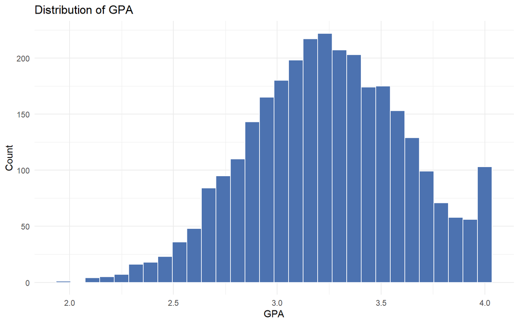

```r
ggplot(df, aes(x = gpa)) +
  geom_histogram(bins = 30, fill = "#4C72B0", color = "white") +
  labs(title = "Distribution of GPA", x = "GPA", y = "Count") +
  theme_minimal()
```

**Observation:** GPA is approximately symmetric and centered around 3.2–3.3, with a slight left skew (a longer tail toward lower GPA values).

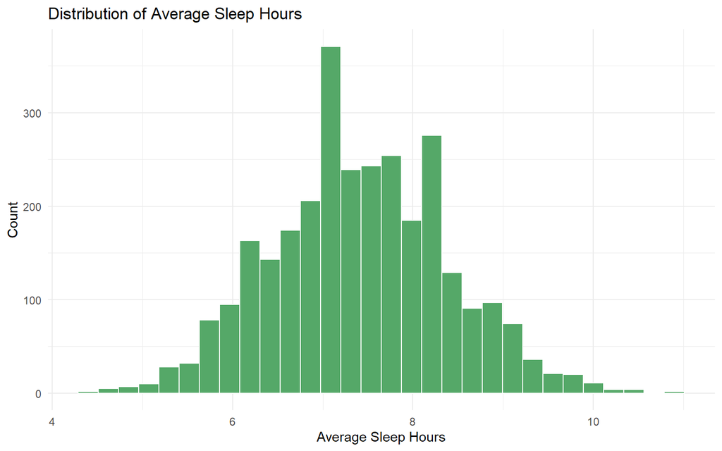

```r
ggplot(df, aes(x = avg_sleep_hours)) +
  geom_histogram(bins = 30, fill = "#55A868", color = "white") +
  labs(title = "Distribution of Average Sleep Hours", x = "Average Sleep Hours", y = "Count") +
  theme_minimal()
```

**Observation:** Sleep hours are roughly bell-shaped, centered near 7–7.5 hours, consistent with typical recommended sleep durations, with a small number of students sleeping far less or far more.

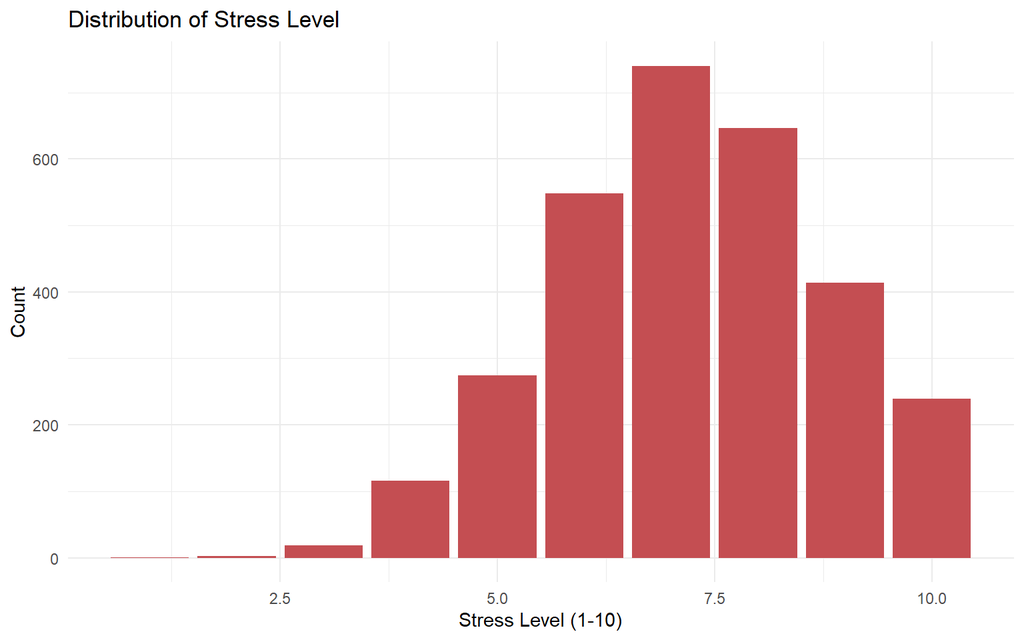

```r
ggplot(df, aes(x = stress_level)) +
  geom_bar(fill = "#C44E52") +
  labs(title = "Distribution of Stress Level", x = "Stress Level (1-10)", y = "Count") +
  theme_minimal()
```

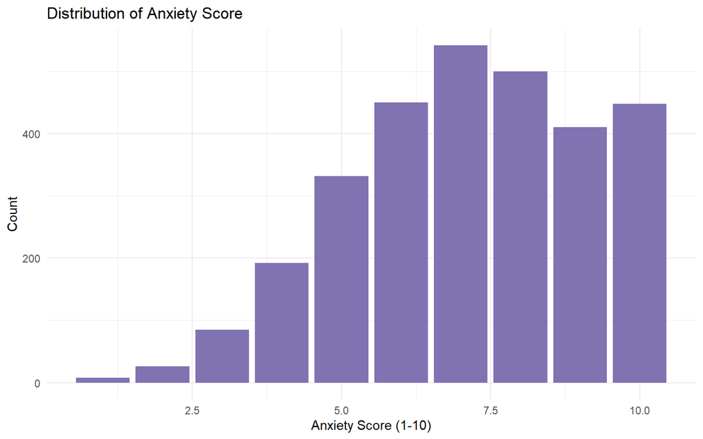

```r
ggplot(df, aes(x = anxiety_score)) +
  geom_bar(fill = "#8172B2") +
  labs(title = "Distribution of Anxiety Score", x = "Anxiety Score (1-10)", y = "Count") +
  theme_minimal()
```

**Observation:** Both stress level and anxiety score are left-skewed, with most students clustered in the higher range (7–9), suggesting that elevated stress and anxiety are common in this sample rather than rare edge cases.

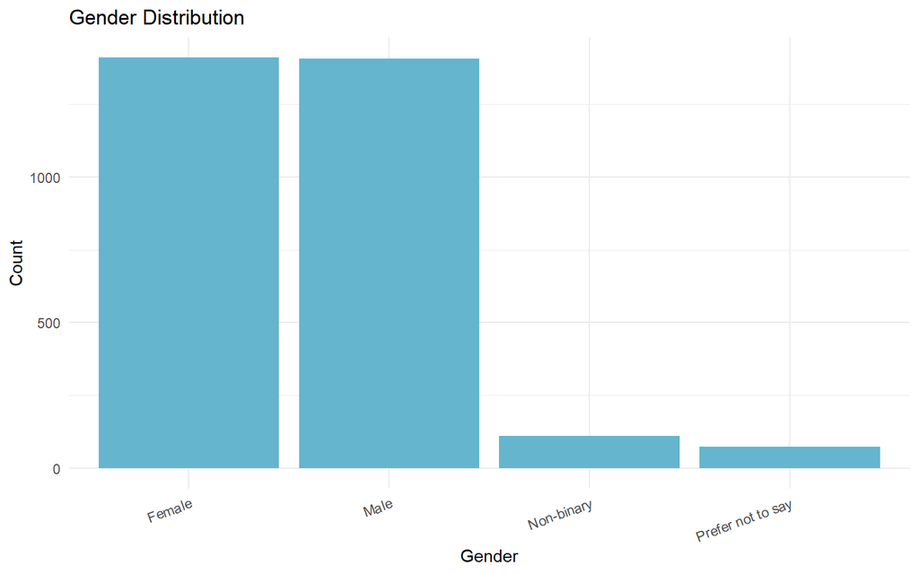

```r
ggplot(df, aes(x = gender)) +
  geom_bar(fill = "#64B5CD") +
  labs(title = "Gender Distribution", x = "Gender", y = "Count") +
  theme_minimal() +
  theme(axis.text.x = element_text(angle = 20, hjust = 1))
```

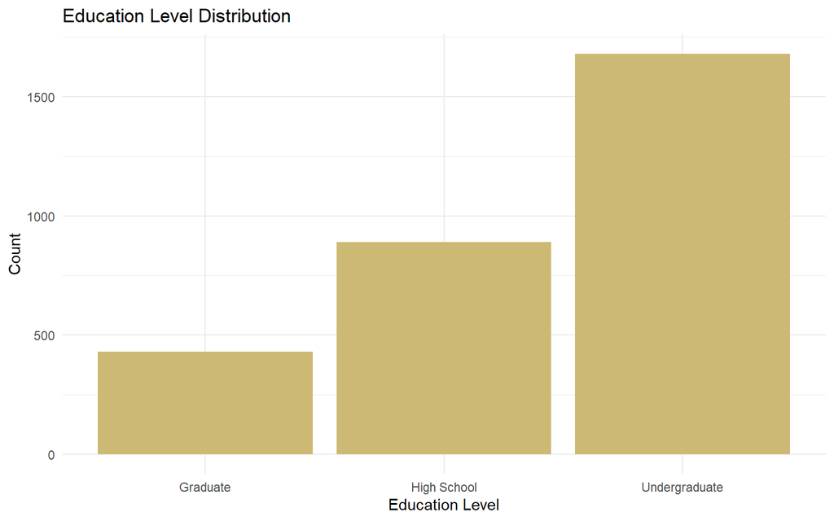

```r
ggplot(df, aes(x = education_level)) +
  geom_bar(fill = "#CCB974") +
  labs(title = "Education Level Distribution", x = "Education Level", y = "Count") +
  theme_minimal()
```

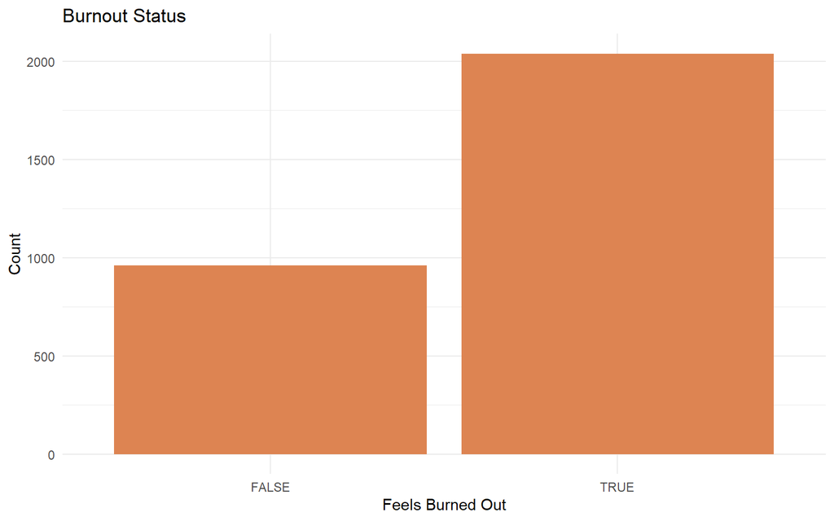

```r
ggplot(df, aes(x = feels_burned_out)) +
  geom_bar(fill = "#DD8452") +
  labs(title = "Burnout Status", x = "Feels Burned Out", y = "Count") +
  theme_minimal()
```

**Observation:** “Undergraduate” is the dominant education level, and the gender variable includes four categories (Male, Female, Non-binary, Prefer not to say). A large proportion of students report feeling burned out, which aligns with the generally high stress/anxiety scores observed above.

## Skewness Analysis

```r
numeric_vars <- df %>% select(age, avg_sleep_hours, screen_time_hours, social_media_hours,
                               study_hours_per_day, exercise_hours_per_week,
                               caffeine_drinks_per_day, stress_level, anxiety_score, gpa)

skew_table <- sapply(numeric_vars, moments::skewness, na.rm = TRUE) %>%
  round(3) %>%
  sort(decreasing = TRUE) %>%
  as.data.frame() %>%
  rownames_to_column("variable") %>%
  rename(skewness = 2)

kable(skew_table, caption = "Skewness of Numeric Variables")
```

Skewness of Numeric Variables

| variable | skewness |
| --- | --- |
| caffeine_drinks_per_day | 0.782 |
| exercise_hours_per_week | 0.359 |
| age | 0.182 |
| avg_sleep_hours | 0.088 |
| study_hours_per_day | 0.087 |
| social_media_hours | 0.020 |
| screen_time_hours | 0.002 |
| gpa | -0.093 |
| stress_level | -0.182 |
| anxiety_score | -0.349 |

## Bivariate Analysis

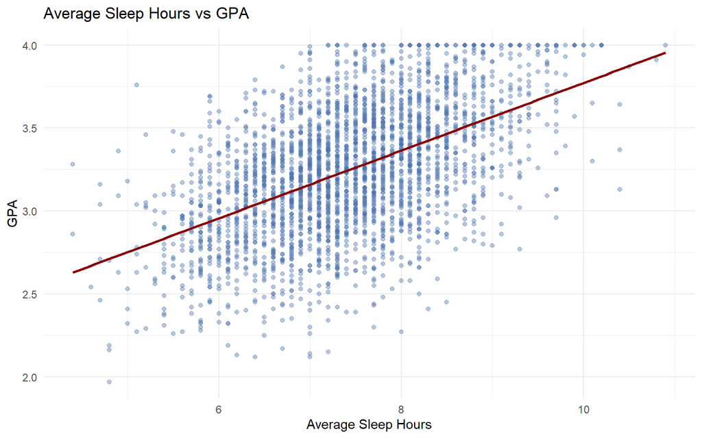

```r
ggplot(df, aes(x = avg_sleep_hours, y = gpa)) +
  geom_point(alpha = 0.4, color = "#4C72B0") +
  geom_smooth(method = "lm", color = "darkred", se = FALSE) +
  labs(title = "Average Sleep Hours vs GPA", x = "Average Sleep Hours", y = "GPA") +
  theme_minimal()
```

**Observation:** There is a clear positive relationship — students who sleep more tend to have higher GPA.

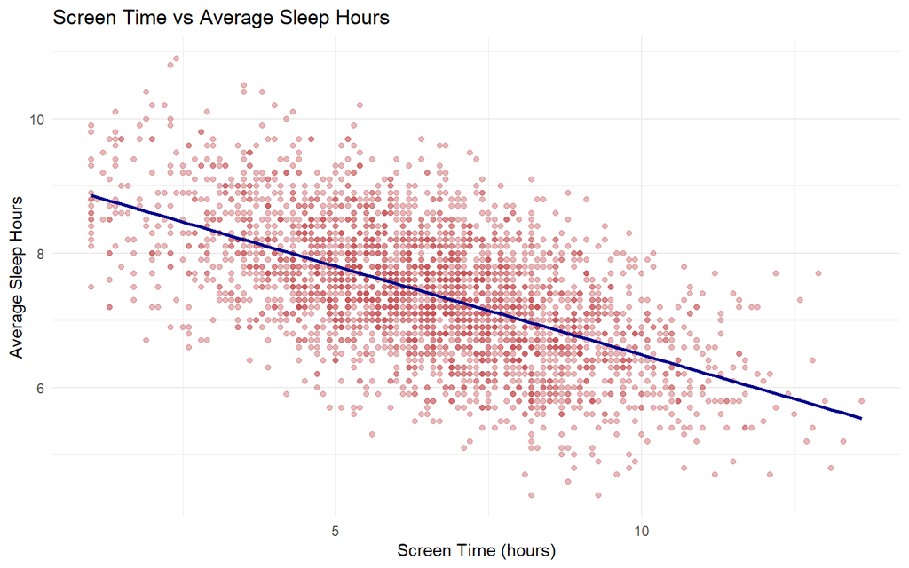

```r
ggplot(df, aes(x = screen_time_hours, y = avg_sleep_hours)) +
  geom_point(alpha = 0.4, color = "#C44E52") +
  geom_smooth(method = "lm", color = "darkblue", se = FALSE) +
  labs(title = "Screen Time vs Average Sleep Hours", x = "Screen Time (hours)", y = "Average Sleep Hours") +
  theme_minimal()
```

**Observation:** A clear negative relationship is visible — students with higher screen time report fewer sleep hours.

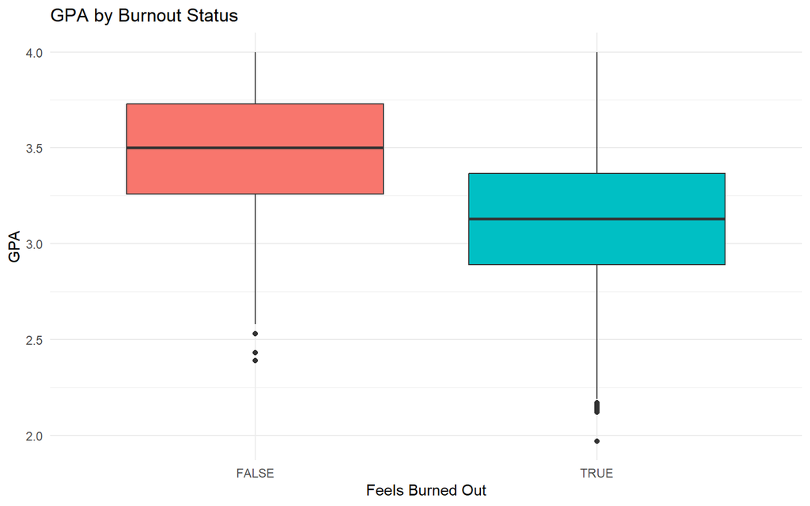

```r
ggplot(df, aes(x = feels_burned_out, y = gpa, fill = feels_burned_out)) +
  geom_boxplot() +
  labs(title = "GPA by Burnout Status", x = "Feels Burned Out", y = "GPA") +
  theme_minimal() +
  theme(legend.position = "none")
```

**Observation:** Students who report feeling burned out tend to have a visibly lower median GPA than those who do not.

```r
df %>%
  group_by(stress_level) %>%
  summarise(mean_gpa = mean(gpa), n = n()) %>%
  kable(caption = "Mean GPA by Stress Level")
```

Mean GPA by Stress Level

| stress_level | mean_gpa | n |
| --- | --- | --- |
| 1 | 4.000000 | 1 |
| 2 | 3.933333 | 3 |
| 3 | 3.785789 | 19 |
| 4 | 3.701724 | 116 |
| 5 | 3.511277 | 274 |
| 6 | 3.420347 | 548 |
| 7 | 3.268068 | 740 |
| 8 | 3.155851 | 646 |
| 9 | 2.993382 | 414 |
| 10 | 2.860167 | 239 |

**Observation:** Mean GPA decreases fairly consistently as stress level increases, reinforcing the negative stress–performance relationship.

## Correlation Analysis

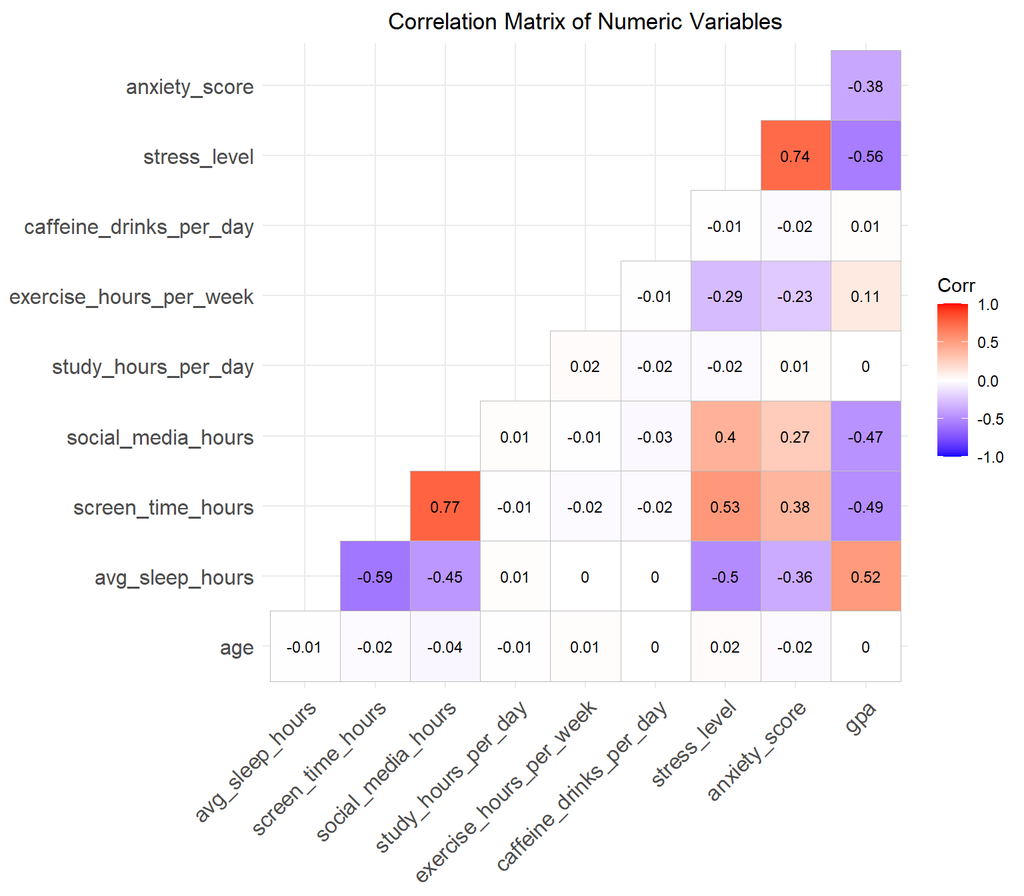

```r
corr_matrix <- cor(numeric_vars, use = "pairwise.complete.obs")
ggcorrplot(corr_matrix, lab = TRUE, lab_size = 3, type = "lower",
           title = "Correlation Matrix of Numeric Variables") +
  theme(plot.title = element_text(hjust = 0.5))
```

**Observation:** `stress_level` and `anxiety_score` are strongly positively correlated (~0.74), flagging a potential multicollinearity concern if both are used together as predictors. `screen_time_hours` and `social_media_hours` are also strongly correlated with each other (~0.77), a second multicollinearity pair. `avg_sleep_hours` shows a strong negative correlation with `screen_time_hours` (~ -0.59) and a moderate positive correlation with `gpa` (~0.52). `stress_level` and `screen_time_hours` both show a fairly strong negative correlation with `gpa` (~ -0.56 and ~ -0.49 respectively), while `study_hours_per_day`, `caffeine_drinks_per_day`, and `age` show low bivariate correlation with GPA.

## Non-Obvious / Interesting Finding

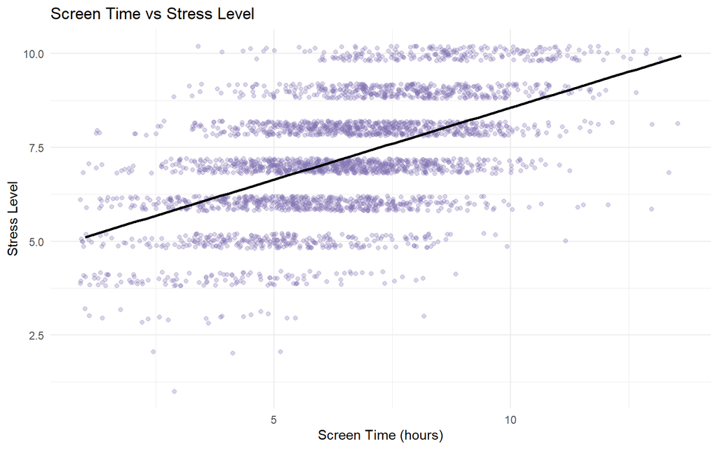

```r
ggplot(df, aes(x = screen_time_hours, y = stress_level)) +
  geom_jitter(alpha = 0.3, color = "#8172B2", width = 0.1, height = 0.2) +
  geom_smooth(method = "lm", color = "black", se = FALSE) +
  labs(title = "Screen Time vs Stress Level", x = "Screen Time (hours)", y = "Stress Level") +
  theme_minimal()
```

**Observation:** Beyond the expected sleep-related effects, screen time is also positively associated with stress level itself — suggesting screen time may affect academic performance and wellbeing through two separate pathways: directly raising stress, and indirectly reducing sleep. This dual-pathway pattern is not obvious from looking at any single pairwise relationship alone.

# Section 4 — Preprocessing & Feature Engineering

## Missing Value Treatment

```r
colSums(is.na(df))
```

```
##              student_id                     age                  gender
##                       0                       0                       0
##         education_level         avg_sleep_hours       screen_time_hours
##                       0                       0                       0
##      social_media_hours     study_hours_per_day exercise_hours_per_week
##                      14                       0                      14
## caffeine_drinks_per_day            stress_level           anxiety_score
##                       0                       0                       7
##                     gpa          uses_sleep_app        feels_burned_out
##                       0                       0                       0
```

**Observation:** `social_media_hours`, `exercise_hours_per_week`, and `anxiety_score` each contain a small number of missing values (14, 14, and 7 respectively), together accounting for well under 1% of all cells in the dataset. There is no obvious pattern suggesting systematic missingness, indicating these are missing completely at random (MCAR).

```r
df <- df %>%
  mutate(
    social_media_hours = if_else(is.na(social_media_hours),
                                  median(social_media_hours, na.rm = TRUE), social_media_hours),
    exercise_hours_per_week = if_else(is.na(exercise_hours_per_week),
                                       median(exercise_hours_per_week, na.rm = TRUE), exercise_hours_per_week),
    anxiety_score = if_else(is.na(anxiety_score),
                             median(anxiety_score, na.rm = TRUE), anxiety_score)
  )

# Confirm no missing values remain
colSums(is.na(df))
```

```
##              student_id                     age                  gender
##                       0                       0                       0
##         education_level         avg_sleep_hours       screen_time_hours
##                       0                       0                       0
##      social_media_hours     study_hours_per_day exercise_hours_per_week
##                       0                       0                       0
## caffeine_drinks_per_day            stress_level           anxiety_score
##                       0                       0                       0
##                     gpa          uses_sleep_app        feels_burned_out
##                       0                       0                       0
```

**Decision:** Rather than dropping rows (which would discard otherwise-complete records for only a handful of missing cells) we impute using the **median** of each affected column. Median is preferred over mean here because all three columns show some skew/outliers, and the median is more robust than the mean.

## Outlier Detection and Treatment

```r
detect_outliers_iqr <- function(x) {
  q1 <- quantile(x, 0.25, na.rm = TRUE)
  q3 <- quantile(x, 0.75, na.rm = TRUE)
  iqr <- q3 - q1
  lower <- q1 - 1.5 * iqr
  upper <- q3 + 1.5 * iqr
  sum(x < lower | x > upper, na.rm = TRUE)
}

outlier_counts <- sapply(numeric_vars, detect_outliers_iqr) %>%
  as.data.frame() %>%
  rownames_to_column("variable") %>%
  rename(n_outliers = 2) %>%
  arrange(desc(n_outliers))

kable(outlier_counts, caption = "IQR-based Outlier Counts per Numeric Variable")
```

IQR-based Outlier Counts per Numeric Variable

| variable | n_outliers |
| --- | --- |
| avg_sleep_hours | 24 |
| study_hours_per_day | 11 |
| age | 10 |
| social_media_hours | 10 |
| exercise_hours_per_week | 10 |
| screen_time_hours | 9 |
| anxiety_score | 8 |
| gpa | 8 |
| caffeine_drinks_per_day | 6 |
| stress_level | 4 |

**Decision:** `avg_sleep_hours` shows the largest number of IQR-flagged outliers, followed by a handful in `study_hours_per_day`, `exercise_hours_per_week`, `social_media_hours`, and `screen_time_hours`. Rather than deleting these rows, we cap (winsorize) extreme values at the IQR fences, since these values are plausible real-world behaviors and not data entry errors — removing them would discard genuine signal.

```r
winsorize_iqr <- function(x) {
  q1 <- quantile(x, 0.25)
  q3 <- quantile(x, 0.75)
  iqr <- q3 - q1
  lower <- q1 - 1.5 * iqr
  upper <- q3 + 1.5 * iqr
  pmin(pmax(x, lower), upper)
}

df_clean <- df %>%
  mutate(across(c(avg_sleep_hours, study_hours_per_day, exercise_hours_per_week,
                   social_media_hours, screen_time_hours), winsorize_iqr))
```

## Categorical Encoding

```r
df_clean <- df_clean %>%
  mutate(uses_sleep_app = as.integer(uses_sleep_app),
         feels_burned_out = as.integer(feels_burned_out))

# base R one-hot encoding using model.matrix
encoded_cats <- model.matrix(~ gender + education_level - 1, data = df_clean) %>%
  as.data.frame()

df_clean <- df_clean %>%
  select(-gender, -education_level) %>%
  bind_cols(encoded_cats)

names(df_clean) <- make.names(names(df_clean))
```

**Decision:** `gender` (4 levels) and `education_level` (3 levels) are one-hot encoded using base R’s `model.matrix()` since they are unordered categorical variables. The two boolean columns (`uses_sleep_app`, `feels_burned_out`) are converted to 0/1 integers.

## Numeric Scaling / Normalization

```r
scale_cols <- c("age", "avg_sleep_hours", "screen_time_hours", "social_media_hours",
                "study_hours_per_day", "exercise_hours_per_week", "caffeine_drinks_per_day",
                "stress_level", "anxiety_score")

# base R standardization (z-score) using scale()
df_scaled <- df_clean
df_scaled[, scale_cols] <- scale(df_clean[, scale_cols])
```

**Justification:** Standardization (z-score scaling) is applied to all numeric predictors because downstream Principal Component Analysis and regularized algorithms are sensitive to differences in variable scale. `gpa` (the target) and `student_id` (an identifier) are left unscaled/excluded.

## Feature Engineering

```r
df_scaled <- df_scaled %>%
  mutate(
    screen_to_sleep_ratio = df_clean$screen_time_hours / df_clean$avg_sleep_hours,
    mental_load_index = (df_clean$stress_level + df_clean$anxiety_score) / 2,
    age_group = case_when(
      df_clean$age < 18 ~ "Teen",
      df_clean$age <= 22 ~ "Young Adult",
      TRUE ~ "Adult"
    )
  )

age_group_encoded <- model.matrix(~ age_group - 1, data = df_scaled) %>% as.data.frame()

df_scaled <- df_scaled %>%
  select(-age_group) %>%
  bind_cols(age_group_encoded)
names(df_scaled) <- make.names(names(df_scaled))
```

**Justification for new features:**

1. **`screen_to_sleep_ratio`** — captures digital overuse relative to rest, a single interaction term that may be more predictive than either raw variable alone.
2. **`mental_load_index`** — combines stress and anxiety (which are highly correlated, ~0.74) into a single composite score, reducing redundancy while retaining the shared signal.
3. **`age_group`** (binned and one-hot encoded) — captures potential non-linear effects of age that a raw numeric age term might miss.

## Feature Selection

```r
corr_with_target <- df_clean %>%
  select(all_of(scale_cols)) %>%
  mutate(gpa = df_clean$gpa) %>%
  cor() %>%
  as.data.frame() %>%
  select(gpa) %>%
  rownames_to_column("variable") %>%
  filter(variable != "gpa") %>%
  arrange(desc(abs(gpa)))

kable(corr_with_target, caption = "Correlation of Each Numeric Predictor with GPA")
```

Correlation of Each Numeric Predictor with GPA

| variable | gpa |
| --- | --- |
| stress_level | -0.5580408 |
| avg_sleep_hours | 0.5227223 |
| screen_time_hours | -0.4922292 |
| social_media_hours | -0.4689409 |
| anxiety_score | -0.3835592 |
| exercise_hours_per_week | 0.1087434 |
| caffeine_drinks_per_day | 0.0087324 |
| age | 0.0046845 |
| study_hours_per_day | 0.0012472 |

```r
low_value_features <- c("age", "caffeine_drinks_per_day")
```

**Method and decision:** We apply a principled correlation-filter approach combined with theoretical domain preservation: predictors with negligible correlation with the target (`gpa`) and no theoretical necessity — namely `age` and `caffeine_drinks_per_day` (both showing |r| < 0.05 with GPA) — are dropped from the feature set saved for downstream modeling. `study_hours_per_day` is explicitly retained despite its low marginal bivariate correlation because controlling for academic study effort is necessary to evaluate Research Question 1 (RQ1) without confounding. `avg_sleep_hours`, `screen_time_hours`, `stress_level`, `anxiety_score`, and `social_media_hours` show the strongest linear association with the target and are retained. `exercise_hours_per_week` (|r| ≈ 0.11) is weaker but clearly non-negligible, so it is also retained. Note that `stress_level` and `anxiety_score` are correlated with each other (~0.74), and `screen_time_hours` with `social_media_hours` (~0.77); the engineered `mental_load_index` partially addresses the first redundancy.

# Saved Cleaned Dataset for Phase 2

```r
df_final <- df_scaled %>% select(-any_of(low_value_features), -student_id)

saveRDS(df_final, "clean_student_sleep_data.rds")
```

# Section 5 — Dimensionality Reduction with PCA

## Principal Component Analysis Implementation

Principal Component Analysis (PCA) is applied to the standardized continuous features to analyze the geometric structure of the predictor space and evaluate variance concentration.

```r
pca_features <- df_scaled %>%
  select(
    avg_sleep_hours,
    screen_time_hours,
    social_media_hours,
    study_hours_per_day,
    exercise_hours_per_week,
    stress_level,
    anxiety_score,
    screen_to_sleep_ratio,
    mental_load_index
  )

pca_model <- prcomp(pca_features, center = TRUE, scale. = TRUE)
summary(pca_model)
```

```
## Importance of components:
##                           PC1    PC2    PC3     PC4     PC5     PC6     PC7
## Standard deviation     2.1204 1.2712 1.0009 0.91405 0.74536 0.49955 0.47964
## Proportion of Variance 0.4996 0.1796 0.1113 0.09283 0.06173 0.02773 0.02556
## Cumulative Proportion  0.4996 0.6791 0.7904 0.88328 0.94501 0.97274 0.99830
##                           PC8       PC9
## Standard deviation     0.1237 1.501e-15
## Proportion of Variance 0.0017 0.000e+00
## Cumulative Proportion  1.0000 1.000e+00
```

## Scree Plot and Cumulative Explained Variance

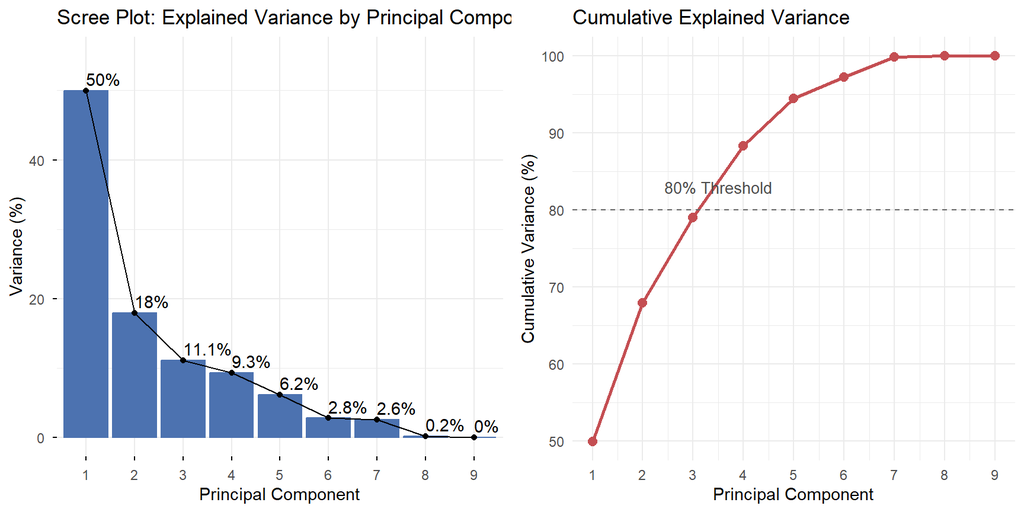

```r
p_scree <- fviz_eig(
  pca_model,
  addlabels = TRUE,
  ylim = c(0, 55),
  barfill = "#4C72B0",
  barcolor = "#4C72B0",
  ggtheme = theme_minimal()
) +
  labs(title = "Scree Plot: Explained Variance by Principal Component", x = "Principal Component", y = "Variance (%)")

eigenvalues <- pca_model$sdev^2
cum_var <- cumsum(eigenvalues) / sum(eigenvalues) * 100

cum_df <- data.frame(
  PC = paste0("PC", 1:length(cum_var)),
  PC_Num = 1:length(cum_var),
  Cumulative_Variance = cum_var
)

p_cum <- ggplot(cum_df, aes(x = PC_Num, y = Cumulative_Variance)) +
  geom_line(color = "#C44E52", linewidth = 1) +
  geom_point(size = 2.5, color = "#C44E52") +
  geom_hline(yintercept = 80, linetype = "dashed", color = "grey40") +
  annotate("text", x = 3.5, y = 83, label = "80% Threshold", color = "grey30", size = 3.5) +
  scale_x_continuous(breaks = 1:9) +
  labs(title = "Cumulative Explained Variance", x = "Principal Component", y = "Cumulative Variance (%)") +
  theme_minimal()

cowplot_available <- requireNamespace("gridExtra", quietly = TRUE)
if (cowplot_available) {
  gridExtra::grid.arrange(p_scree, p_cum, ncol = 2)
} else {
  print(p_scree); print(p_cum)
}
```

**Observation:** - **PC1** accounts for **49.96%** of total variance, and **PC2** accounts for **17.96%**, jointly explaining **67.91%** of total multivariate variance. - Following the **Kaiser Criterion** (eigenvalues $\lambda > 1.0$), the first 3 components ($\lambda_1 = 4.49, \lambda_2 = 1.62, \lambda_3 = 1.00$) explain **79.04%** of cumulative variance. - Retaining 4 components reaches **88.33%** cumulative variance, compressing 9 correlated dimensions into 4 orthogonal axes.

## PCA Variable Loadings and Biplot

```r
loadings_df <- as.data.frame(pca_model$rotation[, 1:3]) %>%
  rownames_to_column("Feature") %>%
  arrange(desc(abs(PC1)))

kable(loadings_df, digits = 3, caption = "Table 5: Variable Loadings for PC1, PC2, and PC3")
```

Table 5: Variable Loadings for PC1, PC2, and PC3

| Feature | PC1 | PC2 | PC3 |
| --- | --- | --- | --- |
| screen_to_sleep_ratio | 0.414 | -0.330 | -0.016 |
| stress_level | 0.397 | 0.299 | 0.000 |
| mental_load_index | 0.396 | 0.392 | 0.028 |
| screen_time_hours | 0.396 | -0.330 | -0.013 |
| anxiety_score | 0.348 | 0.417 | 0.047 |
| avg_sleep_hours | -0.343 | 0.218 | 0.016 |
| social_media_hours | 0.331 | -0.355 | 0.002 |
| exercise_hours_per_week | -0.091 | -0.437 | 0.069 |
| study_hours_per_day | -0.004 | -0.013 | 0.996 |

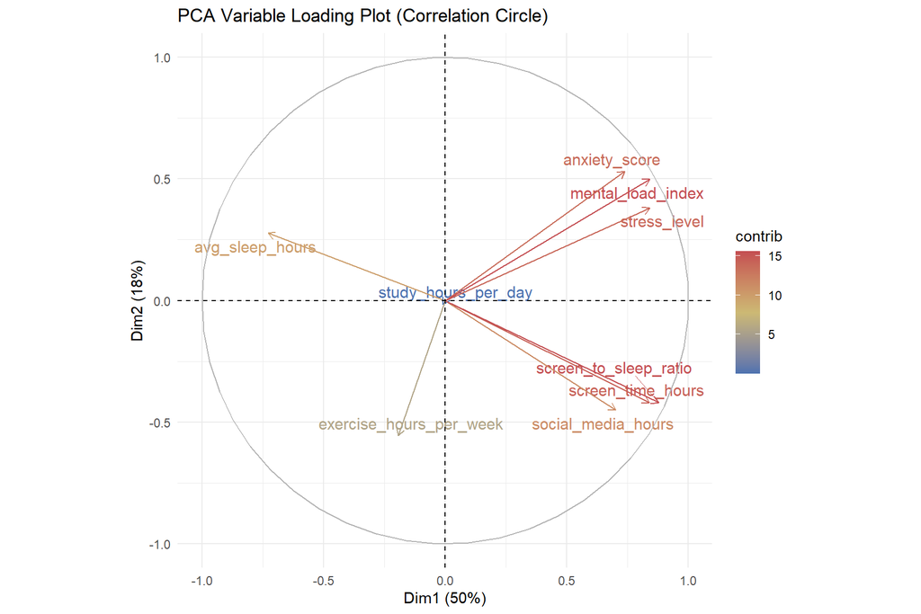

```r
fviz_pca_var(
  pca_model,
  col.var = "contrib",
  gradient.cols = c("#4C72B0", "#CCB974", "#C44E52"),
  repel = TRUE,
  title = "PCA Variable Loading Plot (Correlation Circle)"
) +
  theme_minimal()
```

**Interpretation of Principal Components:** 1. **PC1 (“Digital Overuse vs. Sleep Depletion Axis”):** High positive loadings for `screen_to_sleep_ratio` (+0.414), `stress_level` (+0.397), `mental_load_index` (+0.396), `screen_time_hours` (+0.396), `anxiety_score` (+0.348), and strong negative loading for `avg_sleep_hours` (-0.343). PC1 represents the core lifestyle continuum of digital engagement versus biological rest. 2. **PC2 (“Pure Affective Strain vs. Physical Activity Axis”):** Heavily dominated by `anxiety_score` (+0.417), `mental_load_index` (+0.392), and `stress_level` (+0.299) contrasting with negative loadings on `exercise_hours_per_week` (-0.437) and screen time metrics. 3. **PC3 (“Academic Effort Axis”):** Almost purely isolated by `study_hours_per_day` (+0.996).

## Interpretability Assessment and Feature Strategy

- **Impact on Interpretability:** While PCA successfully eliminates multicollinearity, it transforms intuitive real-world metrics (e.g., “hours of sleep”) into abstract mathematical eigenvectors. For educational policymakers and academic counselors, recommendations phrased in “units of PC1” are difficult to translate into actionable advice.
- **Modelling Strategy Justification:** We train supervised learning models on both the **original engineered feature set** (prioritizing actionable domain interpretability) and compare with a model trained on the **orthogonal PCA component space** (evaluating whether multicollinearity reduction improves generalization).

# Section 6 — Modelling

## Data Partitioning and Cross-Validation Setup

The dataset is partitioned into an $80\%$ training set ($n = 2,401$) for model training and cross-validation, and a $20\%$ hold-out test set ($n = 599$) for final independent evaluation.

```r
set.seed(123)

train_index <- createDataPartition(df_final$gpa, p = 0.80, list = FALSE)
train_set <- df_final[train_index, ]
test_set  <- df_final[-train_index, ]

cat("Training Set Size:", nrow(train_set), "observations\n")
```

```
## Training Set Size: 2401 observations
```

```r
cat("Testing Set Size: ", nrow(test_set), "observations\n")
```

```
## Testing Set Size:  599 observations
```

```r
cv_control <- trainControl(
  method = "cv",
  number = 10,
  savePredictions = "final",
  verboseIter = FALSE
)
```

## Model 1: Baseline Multiple Linear Regression

The baseline model fits an Ordinary Least Squares (OLS) multiple linear regression on all preprocessed predictors.

```r
set.seed(123)
model_lm <- train(
  gpa ~ .,
  data = train_set,
  method = "lm",
  trControl = cv_control
)

summary(model_lm$finalModel)
```

```
##
## Call:
## lm(formula = .outcome ~ ., data = dat)
##
## Residuals:
##     Min      1Q  Median      3Q     Max
## -0.9859 -0.1948  0.0052  0.2015  0.8792
##
## Coefficients: (3 not defined because of singularities)
##                                Estimate Std. Error t value Pr(>|t|)
## (Intercept)                   3.3858804  0.0981685  34.491  < 2e-16 ***
## avg_sleep_hours               0.0818510  0.0138833   5.896 4.26e-09 ***
## screen_time_hours             0.0561090  0.0297820   1.884   0.0597 .
## social_media_hours           -0.0844535  0.0092308  -9.149  < 2e-16 ***
## study_hours_per_day          -0.0039844  0.0058644  -0.679   0.4969
## exercise_hours_per_week       0.0000376  0.0063261   0.006   0.9953
## stress_level                 -0.1362450  0.0124311 -10.960  < 2e-16 ***
## anxiety_score                 0.0143227  0.0086151   1.663   0.0965 .
## uses_sleep_app               -0.0087409  0.0123037  -0.710   0.4775
## feels_burned_out             -0.0248987  0.0208363  -1.195   0.2322
## genderFemale                  0.0165199  0.0399222   0.414   0.6791
## genderMale                   -0.0140919  0.0399013  -0.353   0.7240
## genderNon.binary              0.0097640  0.0491433   0.199   0.8425
## genderPrefer.not.to.say              NA         NA      NA       NA
## education_levelHigh.School    0.0204601  0.0191100   1.071   0.2844
## education_levelUndergraduate  0.0301368  0.0176664   1.706   0.0882 .
## screen_to_sleep_ratio        -0.1608247  0.0940776  -1.709   0.0875 .
## mental_load_index                    NA         NA      NA       NA
## age_groupAdult               -0.0003184  0.0172249  -0.018   0.9853
## age_groupTeen                -0.0068347  0.0136818  -0.500   0.6174
## age_groupYoung.Adult                 NA         NA      NA       NA
## ---
## Signif. codes:  0 '***' 0.001 '**' 0.01 '*' 0.05 '.' 0.1 ' ' 1
##
## Residual standard error: 0.2862 on 2383 degrees of freedom
## Multiple R-squared:  0.4405, Adjusted R-squared:  0.4365
## F-statistic: 110.4 on 17 and 2383 DF,  p-value: < 2.2e-16
```

## Model 2: Improved Tree-Based Model (CART Decision Tree)

A Decision Tree model is tuned across a grid of complexity parameters ($\text{cp}$) using 10-fold cross-validation.

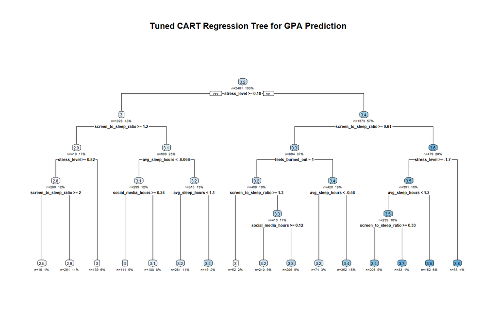

```r
set.seed(123)
tune_grid_tree <- expand.grid(cp = seq(0.001, 0.04, by = 0.003))

model_tree <- train(
  gpa ~ .,
  data = train_set,
  method = "rpart",
  trControl = cv_control,
  tuneGrid = tune_grid_tree
)

rpart.plot(
  model_tree$finalModel,
  type = 2,
  extra = 101,
  under = TRUE,
  box.palette = "Blues",
  main = "Tuned CART Regression Tree for GPA Prediction"
)
```

## Model 3: Improved Ensemble Model (Random Forest)

A Random Forest ensemble is constructed with $B = 200$ regression trees, tuning the number of split candidates ($\text{mtry}$) across 10-fold CV.

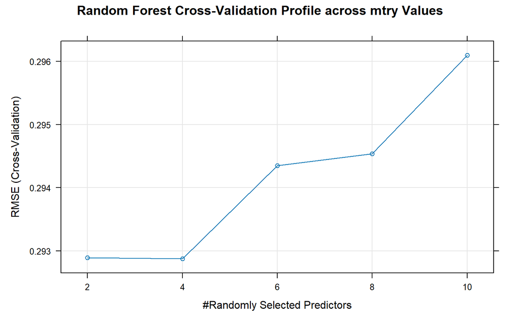

```r
set.seed(123)
tune_grid_rf <- expand.grid(mtry = c(2, 4, 6, 8, 10))

model_rf <- train(
  gpa ~ .,
  data = train_set,
  method = "rf",
  trControl = cv_control,
  tuneGrid = tune_grid_rf,
  ntree = 200,
  importance = TRUE
)

plot(model_rf, main = "Random Forest Cross-Validation Profile across mtry Values")
```

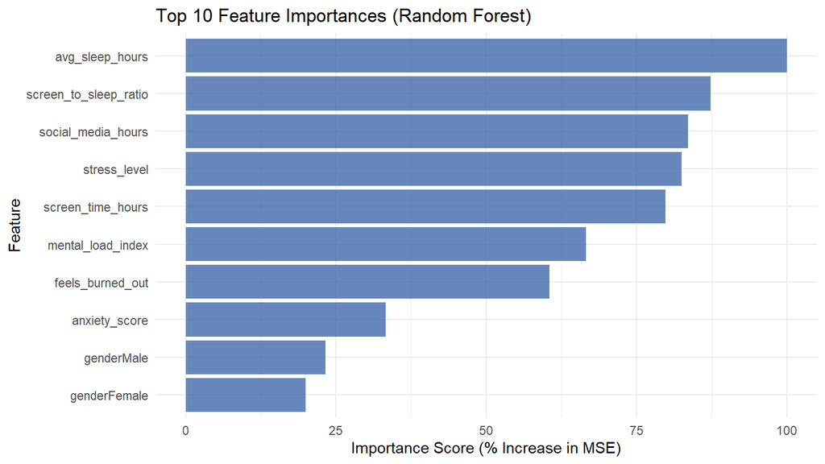

```r
var_imp <- varImp(model_rf)$importance %>%
  rownames_to_column("Feature") %>%
  arrange(desc(Overall)) %>%
  slice_head(n = 10)

ggplot(var_imp, aes(x = reorder(Feature, Overall), y = Overall)) +
  geom_col(fill = "#4C72B0", alpha = 0.85) +
  coord_flip() +
  labs(
    title = "Top 10 Feature Importances (Random Forest)",
    x = "Feature",
    y = "Importance Score (% Increase in MSE)"
  ) +
  theme_minimal()
```

## Model 4: PCA-Transformed Regression Model

A multiple linear regression is trained using the top 4 orthogonal Principal Components.

```r
pca_train_scores <- as.data.frame(predict(pca_model, newdata = pca_features[train_index, ])[, 1:4])
pca_train_df <- bind_cols(gpa = train_set$gpa, pca_train_scores)

pca_test_scores <- as.data.frame(predict(pca_model, newdata = pca_features[-train_index, ])[, 1:4])
pca_test_df <- bind_cols(gpa = test_set$gpa, pca_test_scores)

set.seed(123)
model_pca_lm <- train(
  gpa ~ .,
  data = pca_train_df,
  method = "lm",
  trControl = cv_control
)
```

# Section 7 — Evaluation

## Model Comparison on Cross-Validation and Hold-Out Test Set

```r
calc_eval_metrics <- function(actual, predicted) {
  rmse_val <- sqrt(mean((actual - predicted)^2))
  mae_val  <- mean(abs(actual - predicted))
  ss_res   <- sum((actual - predicted)^2)
  ss_tot   <- sum((actual - mean(actual))^2)
  r2_val   <- 1 - (ss_res / ss_tot)
  return(c(RMSE = rmse_val, MAE = mae_val, R2 = r2_val))
}

pred_lm     <- predict(model_lm, newdata = test_set)
pred_tree   <- predict(model_tree, newdata = test_set)
pred_rf     <- predict(model_rf, newdata = test_set)
pred_pca_lm <- predict(model_pca_lm, newdata = pca_test_df)

cv_results <- rbind(
  `Baseline Linear Regression` = c(RMSE = min(model_lm$results$RMSE), MAE = min(model_lm$results$MAE), R2 = max(model_lm$results$Rsquared)),
  `Decision Tree (CART)`      = c(RMSE = min(model_tree$results$RMSE), MAE = min(model_tree$results$MAE), R2 = max(model_tree$results$Rsquared)),
  `Random Forest (Ensemble)`  = c(RMSE = min(model_rf$results$RMSE), MAE = min(model_rf$results$MAE), R2 = max(model_rf$results$Rsquared)),
  `PCA Linear Regression`     = c(RMSE = min(model_pca_lm$results$RMSE), MAE = min(model_pca_lm$results$MAE), R2 = max(model_pca_lm$results$Rsquared))
)

test_results <- rbind(
  `Baseline Linear Regression` = calc_eval_metrics(test_set$gpa, pred_lm),
  `Decision Tree (CART)`      = calc_eval_metrics(test_set$gpa, pred_tree),
  `Random Forest (Ensemble)`  = calc_eval_metrics(test_set$gpa, pred_rf),
  `PCA Linear Regression`     = calc_eval_metrics(test_set$gpa, pred_pca_lm)
)

comparison_df <- data.frame(
  Model = rownames(test_results),
  CV_RMSE = round(cv_results[, "RMSE"], 4),
  CV_R2   = round(cv_results[, "R2"], 4),
  Test_RMSE = round(test_results[, "RMSE"], 4),
  Test_MAE  = round(test_results[, "MAE"], 4),
  Test_R2   = round(test_results[, "R2"], 4)
)

kable(comparison_df, caption = "Table 6: Comprehensive Model Performance Comparison (10-Fold CV and Test Set)") %>%
  kable_styling(bootstrap_options = c("striped", "hover", "condensed"), full_width = FALSE) %>%
  row_spec(which.min(comparison_df$Test_RMSE), bold = TRUE, background = "#e6f5d0")
```

Table 6: Comprehensive Model Performance Comparison (10-Fold CV and Test Set)

|  | Model | CV_RMSE | CV_R2 | Test_RMSE | Test_MAE | Test_R2 |
| --- | --- | --- | --- | --- | --- | --- |
| Baseline Linear Regression | Baseline Linear Regression | 0.2870 | 0.4360 | 0.2917 | 0.2358 | 0.3852 |
| Decision Tree (CART) | Decision Tree (CART) | 0.3055 | 0.3624 | 0.3108 | 0.2513 | 0.3021 |
| Random Forest (Ensemble) | Random Forest (Ensemble) | 0.2929 | 0.4151 | 0.2973 | 0.2424 | 0.3613 |
| PCA Linear Regression | PCA Linear Regression | 0.2966 | 0.3966 | 0.3013 | 0.2427 | 0.3444 |

## Prediction vs. Actual Visualisations & Residual Diagnostics

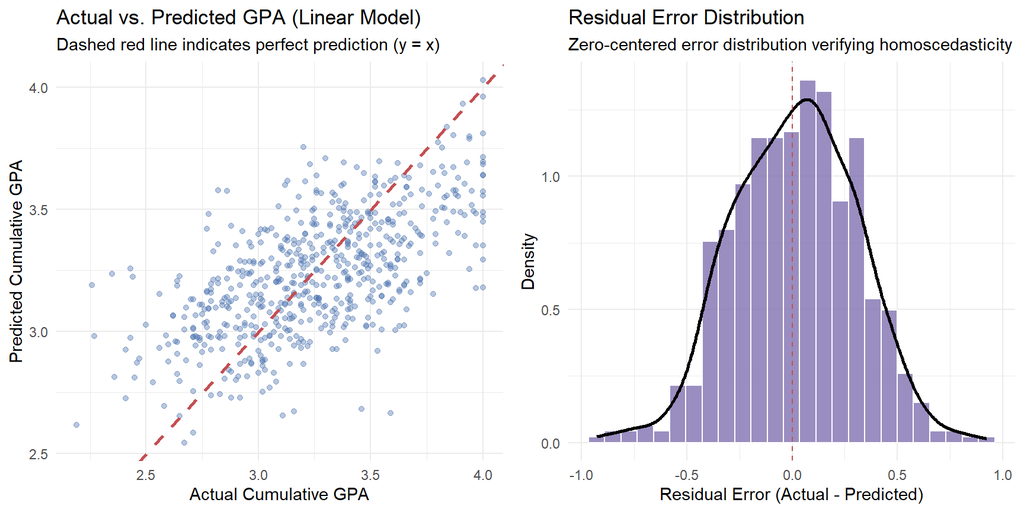

```r
pred_df <- data.frame(
  Actual = test_set$gpa,
  Predicted = pred_lm,
  Residual = test_set$gpa - pred_lm
)

p_pred_scatter <- ggplot(pred_df, aes(x = Actual, y = Predicted)) +
  geom_point(alpha = 0.4, color = "#4C72B0") +
  geom_abline(slope = 1, intercept = 0, color = "#C44E52", linewidth = 1, linetype = "dashed") +
  labs(
    title = "Actual vs. Predicted GPA (Linear Model)",
    subtitle = "Dashed red line indicates perfect prediction (y = x)",
    x = "Actual Cumulative GPA",
    y = "Predicted Cumulative GPA"
  ) +
  theme_minimal()

p_res_dist <- ggplot(pred_df, aes(x = Residual)) +
  geom_histogram(aes(y = after_stat(density)), bins = 25, fill = "#8172B2", color = "white", alpha = 0.8) +
  geom_density(color = "black", linewidth = 1) +
  geom_vline(xintercept = 0, color = "#C44E52", linetype = "dashed") +
  labs(
    title = "Residual Error Distribution",
    subtitle = "Zero-centered error distribution verifying homoscedasticity",
    x = "Residual Error (Actual - Predicted)",
    y = "Density"
  ) +
  theme_minimal()

if (cowplot_available) {
  gridExtra::grid.arrange(p_pred_scatter, p_res_dist, ncol = 2)
} else {
  print(p_pred_scatter); print(p_res_dist)
}
```

## Domain-Level Interpretation

# Section 8 — Communication

## Publication-Quality Visualization (Directly Answering RQ1)

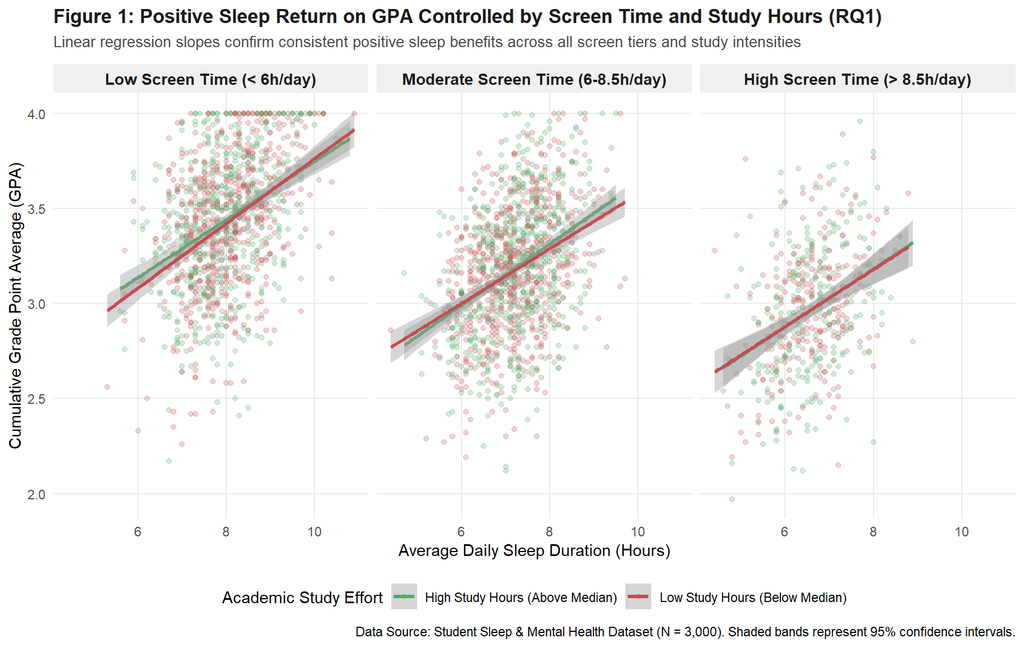

```r
vis_data <- df %>%
  mutate(
    Screen_Category = case_when(
      screen_time_hours < 6.0 ~ "Low Screen Time (< 6h/day)",
      screen_time_hours <= 8.5 ~ "Moderate Screen Time (6-8.5h/day)",
      TRUE ~ "High Screen Time (> 8.5h/day)"
    ),
    Screen_Category = factor(Screen_Category, levels = c(
      "Low Screen Time (< 6h/day)",
      "Moderate Screen Time (6-8.5h/day)",
      "High Screen Time (> 8.5h/day)"
    )),
    Study_Category = if_else(study_hours_per_day >= median(study_hours_per_day, na.rm = TRUE),
                             "High Study Hours (Above Median)", "Low Study Hours (Below Median)")
  )

ggplot(vis_data, aes(x = avg_sleep_hours, y = gpa, color = Study_Category)) +
  geom_point(alpha = 0.25, size = 1.4) +
  geom_smooth(method = "lm", se = TRUE, linewidth = 1.2) +
  facet_wrap(~ Screen_Category) +
  scale_color_manual(
    values = c("High Study Hours (Above Median)" = "#55A868", "Low Study Hours (Below Median)" = "#C44E52"),
    name = "Academic Study Effort"
  ) +
  labs(
    title = "Figure 1: Positive Sleep Return on GPA Controlled by Screen Time and Study Hours (RQ1)",
    subtitle = "Linear regression slopes confirm consistent positive sleep benefits across all screen tiers and study intensities",
    x = "Average Daily Sleep Duration (Hours)",
    y = "Cumulative Grade Point Average (GPA)",
    caption = "Data Source: Student Sleep & Mental Health Dataset (N = 3,000). Shaded bands represent 95% confidence intervals."
  ) +
  theme_minimal(base_size = 11) +
  theme(
    plot.title = element_text(face = "bold", size = 13, color = "#1a1a1a"),
    plot.subtitle = element_text(size = 10, color = "#4a4a4a", margin = ggplot2::margin(b = 10)),
    strip.text = element_text(face = "bold", size = 10.5),
    strip.background = element_rect(fill = "#f0f0f0", color = NA),
    legend.position = "bottom",
    panel.grid.minor = element_blank()
  )
```

# Section 9 — Reflection

## Critical Limitations of the Analysis

1. **Cross-Sectional Observational Design:** The dataset is cross-sectional, capturing a single temporal snapshot. While the statistical associations are strong and theoretically grounded, observational data cannot rule out reverse causality (e.g., poor academic performance causing acute stress and subsequent sleep disruption).
2. **Self-Report Measurement Inaccuracies:** Key metrics—particularly study hours, screen time, and emotional states—rely on subjective self-reporting, introducing recall inaccuracy and potential social desirability biases.
3. **Unmeasured Confounders:** Crucial institutional and socio-economic variables, such as course difficulty, employment commitments, socioeconomic status, and preexisting clinical conditions, were unrecorded in the dataset.

## Ethical Considerations and Fairness

- **Algorithmic Fairness in Academic Evaluation:** Predictive models of student GPA must never be used punitively or as gatekeeping filters for scholarships, admissions, or course enrollment. Using mental health or burnout status in automated decision-making risks reinforcing systemic vulnerabilities and penalizing students during crises.
- **Student Privacy and Digital Surveillance:** Interventions aimed at tracking student screen time or sleep habits must strictly respect digital privacy. Universities must avoid intrusive tracking applications, ensuring all wellness data collection is voluntary, anonymized, and decoupled from academic grading.

## Actionable Directions for Future Work

1. **Longitudinal Telemetry Study with Wearable Sensors:** Transition from self-reported surveys to longitudinal studies utilizing passive biometric wearables (e.g., smart rings, actigraphy monitors) and verified application telemetry. Tracking sleep architecture (REM vs. deep sleep) and daily screen habits over multiple consecutive semesters would clarify true temporal and causal mechanisms.
2. **Randomized Institutional Wellness Intervention Trials:** Conduct controlled institutional intervention trials comparing students participating in structured sleep hygiene and mindfulness workshops versus a control cohort. Measuring post-intervention changes in GPA, anxiety scores, and burnout rates would validate high-impact policy initiatives.